# Dá para cortar?

Antes mesmo da epidemia chegar ao município de Feira de Santana, a Câmara de Vereadores já era conhecida por seus gastos extravagantes. A casa já chegou a gastar, de uma só vez, [17.767,60 em iogurtes](https://www.blogdovelame.com/camara-de-feira-ja-chegou-a-comprar-616-unidades-de-iogurte-de-uma-so-vez/) e disponibilizar 60 linhas de telefone celular para uso dos vereadores , apesar dos gastos [R$ 40 mil anuais com a Telemar](https://www.blogdovelame.com/camara-de-feira-ja-chegou-a-comprar-616-unidades-de-iogurte-de-uma-so-vez/).

Muitas Câmaras tem se mobilizado para cortar gastos e repassar a verba para que a prefeitura utilize nos esforços para conter a pandemia.

Nesse texto vamos conhecer um pouco melhor as despesas da Câmara e o que pode ser cortado para ajudar o município na crise do COVID-19.

## As despesas da Câmara Municipal

Antes, vamos entender um pouco sobre as despesas, segundo a própria Câmara:

> São todos os gastos feitos pela Câmara. As Despesas são divididas em:
> - Despesas correntes. Aquelas necessárias à manutenção dos serviços públicos, como as despesas com material de consumo, telefone, pessoal, serviços de terceiros, etc.
> - Despesas de capital. São os investimentos, ou seja, gastos com novos equipamentos e obras, como construção e reforma de escolas, hospitais, postos de saúde, pavimentação, etc. Os registros de classificação da despesa são efetuados por meio de rotinas específicas e de forma geral podem ser assim tratadas:
> - Valor Orçado (Dotação Orçamentária) - Dependem de autorização legislativa e correspondem ao valor a ser utilizado para a manutenção da Administração Pública;
> - Valor Empenhado - Consiste na reserva da dotação orçamentária para um fim específico, devendo registrar o nome/razão social do credor, valor e descrição do que será pago;
> - Valor Liquidado - Registra efetivamente a despesa executada. No entanto, por ocasião do encerramento do exercício, conforme as normas da Lei Federal n° 4.320/1964, as despesas empenhadas e ainda não liquidadas são inscritas em restos a pagar não processados;
> - Valor Pago - Consiste na entrega do numerário ao credor e só pode ser efetuado após regular liquidação da despesa.

Fonte: https://www.transparencia.feiradesantana.ba.leg.br/index.php?view=despesasinfo

No [portal da transparência](https://www.transparencia.feiradesantana.ba.leg.br/index.php?view=despesasinfo) podemos verificar os gastos nas três fases: empenho, liquidação e pagamento. Cada despesa apresenta também as seguintes informações:

[figure not shown]

- Data
- Fase
- Credor (Empresa ou pessoa física)
- Valor
- Número
- Documento (o CPF ou CNPJ da empresa ou pessoa)
- Número do processo
- Bem / Serviço prestado
- Natureza
- Função
- Subfunção
- Processo licitatório
- Fonte de recurso

Mas como saber qual valor pode ser gasto pelo município durante o ano?

## Lei Orçamentária

O valor que o município pode gastar, bem como a receita esperada, é estabelecido pela Lei Orçamentária Anual (LOA). Todos os anos o município deve estabelecer um orçamento para o ano seguinte. Saiba mais sobre isso [aqui](https://www.politize.com.br/ppa-ldo-loa-3-siglas-que-definem-orcamento-governo/).

Embora esteja publicada no diário oficial, a LOA de Feira de Santana não foi encontrada facilmente nos portais da transparência da prefeitura e da câmara. Você pode acessá-la [aqui](http://www.diariooficial.feiradesantana.ba.gov.br/atos/executivo/1JE1WJ2162019.pdf).

```python
import pandas as pd
import numpy as np
import matplotlib.pyplot as plt
```

Baixe os dados das despesas da Câmara aqui:

https://www.kaggle.com/anapaulagomes/despesas-da-cmara-municipal

Descompacte o arquivo e coloque na pasta `analysis`.

```python
despesas = pd.read_csv('expenses-11.04.2020.csv')
despesas.head()
```

|  | company_or_person | crawled_at | crawled_from | date | document | function | group | legal_status | number | phase | process_number | published_at | resource | subfunction | subgroup | summary | type_of_process | value |
| --- | --- | --- | --- | --- | --- | --- | --- | --- | --- | --- | --- | --- | --- | --- | --- | --- | --- | --- |
| 0 | EDITORA PRINCESA LTDA | 2020-04-11 10:12:39.549868 | https://www.transparencia.feiradesantana.ba.le... | 2010-01-04 | 00.725.755/0001-62 | 01 - LEGISLATIVA | Manutencao dos servicos tecnico administrativos | 339039680000 - Serv.de Publicidade e propagand... | 062/2010 | empenho | 029/2010 | 2010-01-04 | 0000 - TESOURO | 031 - ACAO | Serv.de Publicidade e propaganda | IMPORTE DESTINADO PUBLICACAO DE ATOS OFICIAIS ... | DISPENSA | 130.00 |
| 1 | CEDRO EDITORA GRAFICA LTDA | 2020-04-11 10:12:39.553791 | https://www.transparencia.feiradesantana.ba.le... | 2010-01-04 | 00.597.920/0001-30 | 01 - LEGISLATIVA | Manutencao dos servicos tecnico administrativos | 339039680000 - Serv.de Publicidade e propagand... | 063/2010 | empenho | 030/2010 | 2010-01-04 | 0000 - TESOURO | 031 - ACAO | Serv.de Publicidade e propaganda | IMPORTE DESTINADO A PUBLICACAO DE ATOS OFICIAI... | DISPENSA | 360.00 |
| 2 | ELEVADORES OTIS LTDA | 2020-04-11 10:12:39.561768 | https://www.transparencia.feiradesantana.ba.le... | 2010-01-04 | 02.973.973/0010-01 | 01 - LEGISLATIVA | Manutencao dos servicos tecnico administrativos | 339039150000 - Manut.e Conserv.de Maq.e Equipa... | 041/2010 | empenho | 019/2010 | 2010-01-04 | 0000 - TESOURO | 031 - ACAO | Manut.e Conserv.de Maq.e Equipament | IMPORTE DESTINADO A PAGAMENTO DE SERVICO DE MA... | DISPENSA | 5,166.72 |
| 3 | EMPR. BRAS. DE CORREIOS E TELE | 2020-04-11 10:12:39.564685 | https://www.transparencia.feiradesantana.ba.le... | 2010-01-04 | 03.402.831/3861-17 | 01 - LEGISLATIVA | Manutencao dos servicos tecnico administrativos | 339039740000 - Outros Serv. de Terc.-P. Juridi... | 042/2010 | empenho | 020/2010 | 2010-01-04 | 0000 - TESOURO | 031 - ACAO | Outros Serv. de Terc.-P. Juridica | IMPORTE DESTINADO A PAGAMENTO DE SERVICO DE CO... | DISPENSA | 35,000.00 |
| 4 | COMANDOS TERC. E SEG. ELETR. L | 2020-04-11 10:12:39.572683 | https://www.transparencia.feiradesantana.ba.le... | 2010-01-04 | 00.046.493/0001-07 | 01 - LEGISLATIVA | Manutencao dos servicos tecnico administrativos | 339039600000 - Vigilancia Ostensiva ... | 021/2010 | empenho | 013/2010 | 2010-01-04 | 0000 - TESOURO | 031 - ACAO | Vigilancia Ostensiva | IMPORTE DESTINADO A PAGAMENTO ... | DISPENSA | 2,260.00 |

```python
columns = ['crawled_at', 'crawled_from', 'function', 'published_at', 'resource', 'subfunction']
despesas.drop(columns, inplace=True, axis=1)

despesas["date"] = pd.to_datetime(despesas["date"])
despesas = despesas[despesas["date"].isin(pd.date_range("2019-01-01", "2019-12-31"))]
despesas['month'] = despesas['date'].apply(lambda x : x.month)

despesas = despesas.sort_values('date', ascending=False)
despesas.head()
```

|  | company_or_person | date | document | group | legal_status | number | phase | process_number | subgroup | summary | type_of_process | value | month |
| --- | --- | --- | --- | --- | --- | --- | --- | --- | --- | --- | --- | --- | --- |
| 34863 | FUNCIONARIOS EFETIVOS | 2019-12-27 | 14.488.415/0001-60 | Administracao de pessoal e encargos | 319011010000 - V.Vant.Fixas P.Civil(Ve.Base Fo... | 01814-19 | liquidacao | NaN | V.Vant.Fixas P.Civil(Ve.Base Folha) | REF. A VENCIMENTOS DOS SERVIDORES EFETIVOS, FO... | ISENTO | 39,404.46 | 12 |
| 34862 | FUNCIONARIOS CARGOS EM COMISSA | 2019-12-27 | 14.488.415/0001-60 | Administracao de pessoal e encargos | 319011010000 - V.Vant.Fixas P.Civil(Ve.Base Fo... | 01813-19 | liquidacao | NaN | V.Vant.Fixas P.Civil(Ve.Base Folha) | REF. A VENCIMENTOS DOS SERVIDORES CARGOS EM CO... | ISENTO | 18,784.12 | 12 |
| 34861 | CAIXA ECONOMICA FEDERAL | 2019-12-27 | 00.360.305/1611-16 | Manutencao dos servicos tecnico administrativos | 339039999300000000 - Serviços Bancários ... | 19000581 | empenho | NaN | Serviços Bancários | ANULACAO PARCIAL DO EMPENHO DE NUMERO 19000533 | ISENTO | -328.89 | 12 |
| 34899 | EMPRESTIMO CEF | 2019-12-27 | 14.488.415/0001-60 | NaN | NaN | 01816-19 | pagamento | NaN | NaN | PAGAMENTO EXTRA-ORCAMENTARIO NUMERO:000403 | NaN | 37,753.71 | 12 |
| 34898 | I.R.R.F. - FOLHA | 2019-12-27 | 14.488.415/0001-60 | NaN | NaN | 01815-19 | pagamento | NaN | NaN | PAGAMENTO EXTRA-ORCAMENTARIO NUMERO:000402 | NaN | 2,076.69 | 12 |

```python
despesas.shape
```

```
(3709, 13)
```

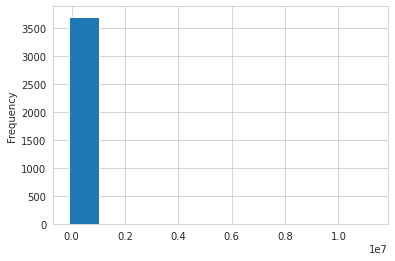

```python
despesas['value'].plot(kind='hist')
```

## Análises por classificação das despesas

> O plano de contas da despesa orçamentária da Câmara está correto, pois segue ao estabelecido pelo TCM-BA, conforme Ato nº 456/2019. O código 33903005 se refere à Material de processamento de dados. Importante lembrar que a STN determina os elementos de despesa, de acordo com a Portaria Interministerial nº 163/2001, mas os desdobramentos da despesa (subelementos) são determinados pelo TCM BA. Segue em anexo o ato normativo com os códigos de despesa.

ESPECIFICAÇÃO DE DESPESA 2020

https://www.tcm.ba.gov.br/contabilidade-municipal/

Faça o download do arquivo `.csv` do natureza das despesas [aqui](https://gist.githubusercontent.com/anapaulagomes/379525586f941a1183aa448dad282f90/raw/378f01c23f0ead542a88fde6274b12ba82b84f8e/especificacao-despesas-tcm-bahia.csv) e coloque na pasta `analysis`.

### Categoria econômica

CATEGORIA ECONÔMICA: a despesa orçamentária, assim como a receita orçamentária, é classificada em duas categorias econômicas:

3-DESPESAS CORRENTES: classificam-se nesta categoria todas as despesas que não contribuem, diretamente, para a formação ou aquisição de um bem de capital.

4 -DESPESAS DE CAPITAL: classificam-se nesta categoria aquelas despesas que contribuem, diretamente, para a formação ou aquisição de um bem de capital

```python
despesas["legal_status"].unique()
```

```
array(['319011010000 - V.Vant.Fixas P.Civil(Ve.Base Folha) 2001 - Administracao de pessoal e encargos',
       '339039999300000000 - Serviços Bancários                                             2002 - Manutencao dos servicos tecnico administrativos',
       nan,
       '339039999600 - Manutenção e conservação de máquinas2002 - Manutencao dos servicos tecnico administrativos',
       '339039999300 - Serviços Bancários                  2002 - Manutencao dos servicos tecnico administrativos',
       '339047000000 - Obrigacoes Trib. e Contributivas    2002 - Manutencao dos servicos tecnico administrativos',
       '339039930000 - Serviços Bancários                  2002 - Manutencao dos servicos tecnico administrativos',
       '339039940000 - Seguros em Geral                    2002 - Manutencao dos servicos tecnico administrativos',
       '319113020000 - Cont.p/Reg.Proprio Prev.ser.RPPS    2001 - Administracao de pessoal e encargos',
       '339039010000 - Publicidades e Propaganda           2002 - Manutencao dos servicos tecnico administrativos',
       '339039999900 - Outros Serv.Terceiros - P. Juridica 2002 - Manutencao dos servicos tecnico administrativos',
       '339030060000 - Material P/manuntençao de Veiculos  2002 - Manutencao dos servicos tecnico administrativos',
       '319013010000000000 - Cont.p/Reg.Geral Prev.INSS                                     2001 - Administracao de pessoal e encargos',
       '319011010000000000 - V.Vant.Fixas P.Civil(Ve.Base Folha)                            2001 - Administracao de pessoal e encargos',
       '319013010000000000 - Cont.p/Reg.Geral Prev.INSS                                     2003 - Administracao da acao legislativa',
       '339049000000000000 - Auxilio - Transporte                                           2002 - Manutencao dos servicos tecnico administrativos',
       '339047000000000000 - Obrigacoes Trib. e Contributivas                               2002 - Manutencao dos servicos tecnico administrativos',
       '339039992500 - Vale refeição/vale alimentação      2002 - Manutencao dos servicos tecnico administrativos',
       '339039090000 - Serviços de Telefonia               2002 - Manutencao dos servicos tecnico administrativos',
       '339039090000000000 - Serviços de Telefonia                                          2002 - Manutencao dos servicos tecnico administrativos',
       '339039998900 - Outros Serv.Terceiros - P. Juridica 2002 - Manutencao dos servicos tecnico administrativos',
       '319113020000 - Cont.p/Reg.Proprio Prev.ser.RPPS    2003 - Administracao da acao legislativa',
       '319013010000 - Cont.p/Reg.Geral Prev.INSS          2001 - Administracao de pessoal e encargos',
       '339039992400 - Assinaturas de periódicos e pagament2002 - Manutencao dos servicos tecnico administrativos',
       '339040000000 - Servicos de Tecnlogia da Informacao 2002 - Manutencao dos servicos tecnico administrativos',
       '339033010000 - Despesas com passagem Aérea         2002 - Manutencao dos servicos tecnico administrativos',
       '319013010000 - Cont.p/Reg.Geral Prev.INSS          2003 - Administracao da acao legislativa',
       '339039010000000000 - Publicidades e Propaganda                                      2002 - Manutencao dos servicos tecnico administrativos',
       '319113020000000000 - Cont.p/Reg.Proprio Prev.ser.RPPS                               2003 - Administracao da acao legislativa',
       '339039999900000000 - Outros Serv.Terceiros - P. Juridica - Demais serviços          2002 - Manutencao dos servicos tecnico administrativos',
       '339036999900 - Outros Serv.de Terceiros-P. Fisica  2002 - Manutencao dos servicos tecnico administrativos',
       '339049000000 - Auxilio - Transporte                2002 - Manutencao dos servicos tecnico administrativos',
       '319011010000 - V.Vant.Fixas P.Civil(Ve.Base Folha) 2003 - Administracao da acao legislativa',
       '339036030000 - Estagiários e Monitores             2002 - Manutencao dos servicos tecnico administrativos',
       '339030999900 - Materiais de Consumo - Outros       2002 - Manutencao dos servicos tecnico administrativos',
       '339030020000 - Combustíveis e Lubrificantes        2002 - Manutencao dos servicos tecnico administrativos',
       '339034019900 - Out.Serv.de Tercerizaçao-P.Jurídica 2002 - Manutencao dos servicos tecnico administrativos',
       '339034010100 - Out.Serv.de Tercerizaçao-P.Jurídica 2002 - Manutencao dos servicos tecnico administrativos',
       '339039110000 - Serviços de Fornecimnto de Agua     2002 - Manutencao dos servicos tecnico administrativos',
       '339014000000 - Diarias-Civil                       2001 - Administracao de pessoal e encargos',
```

[output cut: 53 more lines]

```
       '339030991900000000 - Materiais de Consumo - uniformes e fardamentos                 2002 - Manutencao dos servicos tecnico administrativos',
       '339039120000 - Serviços de Cópias de Encardenaçoes 2002 - Manutencao dos servicos tecnico administrativos',
       '339033020000 - Despesas com passagem Terrestre     2002 - Manutencao dos servicos tecnico administrativos',
       '339030050000000000 - Material de Processamentos de Dados                            2002 - Manutencao dos servicos tecnico administrativos',
       '449039990000 - Outros Servicos Terceiro P. Juridica2002 - Manutencao dos servicos tecnico administrativos',
       '339030992000 - Materiais de Consumo - material para2002 - Manutencao dos servicos tecnico administrativos',
       '339030992000000000 - Materiais de Consumo - material para comunicações              2002 - Manutencao dos servicos tecnico administrativos',
       '339039120000000000 - Serviços de Cópias de Encardenaçoes                            2002 - Manutencao dos servicos tecnico administrativos',
       '339039150000 - Locaçao de Software                 2002 - Manutencao dos servicos tecnico administrativos',
       '339030991300 - Materiais de Consumo - gás e outros 2002 - Manutencao dos servicos tecnico administrativos',
       '339039999100000000 - Outros Serv.Terceiros - P. Juridica - Serviços gerais e adm    2002 - Manutencao dos servicos tecnico administrativos',
       '339039150000000000 - Locaçao de Software                                            2002 - Manutencao dos servicos tecnico administrativos',
       '339030991300000000 - Materiais de Consumo - gás e outros materiais engarrafados     2002 - Manutencao dos servicos tecnico administrativos',
       '449039150000000000 - Locacao de Software                                            2002 - Manutencao dos servicos tecnico administrativos'],
      dtype=object)
```

```python
classificacao = pd.read_csv(
    'especificacao-despesas-tcm-bahia.csv',
    dtype={'Codigo': str, 'Descricao': str, 'Codigo Superior': str}
)
classificacao
```

|  | Codigo | Descricao | Codigo Superior |
| --- | --- | --- | --- |
| 0 | 30000000 | Despesas Correntes | 0 |
| 1 | 31000000 | Pessoal e Encargos Sociais | 30000000 |
| 2 | 31300000 | Transferências a Estados e ao Distrito Federal | 31000000 |
| 3 | 31301100 | Vencimentos e Vantagens Fixas - Pessoal Civil | 31300000 |
| 4 | 31301101 | Vencimento e vantagens fixas Pessoal Civil (Ve... | 31301100 |
| ... | ... | ... | ... |
| 2479 | 77999999 | Reserva Orçamentária do RPPS | 77999900 |
| 2480 | 88880000 | Recursos Provenientes de Veto | 0 |
| 2481 | 88888800 | Recursos Provenientes de Veto | 88880000 |
| 2482 | 99999900 | Reservas | 0 |
| 2483 | 99999999 | Reserva de Contingência | 99999900 |

2484 rows × 3 columns

```python
despesas['classificacao'] = despesas['legal_status'].str.extract('(\d{8})')

despesas_com_classificacao = despesas.merge(classificacao, left_on=['classificacao'], right_on=['Codigo'], how='left')
despesas_com_classificacao
```

|  | company_or_person | date | document | group | legal_status | number | phase | process_number | subgroup | summary | type_of_process | value | month | classificacao | Codigo | Descricao | Codigo Superior |
| --- | --- | --- | --- | --- | --- | --- | --- | --- | --- | --- | --- | --- | --- | --- | --- | --- | --- |
| 0 | FUNCIONARIOS EFETIVOS | 2019-12-27 | 14.488.415/0001-60 | Administracao de pessoal e encargos | 319011010000 - V.Vant.Fixas P.Civil(Ve.Base Fo... | 01814-19 | liquidacao | NaN | V.Vant.Fixas P.Civil(Ve.Base Folha) | REF. A VENCIMENTOS DOS SERVIDORES EFETIVOS, FO... | ISENTO | 39,404.46 | 12 | 31901101 | 31901101 | Vencimento e vantagens fixas Pessoal Civil (Ve... | 31901100 |
| 1 | FUNCIONARIOS CARGOS EM COMISSA | 2019-12-27 | 14.488.415/0001-60 | Administracao de pessoal e encargos | 319011010000 - V.Vant.Fixas P.Civil(Ve.Base Fo... | 01813-19 | liquidacao | NaN | V.Vant.Fixas P.Civil(Ve.Base Folha) | REF. A VENCIMENTOS DOS SERVIDORES CARGOS EM CO... | ISENTO | 18,784.12 | 12 | 31901101 | 31901101 | Vencimento e vantagens fixas Pessoal Civil (Ve... | 31901100 |
| 2 | CAIXA ECONOMICA FEDERAL | 2019-12-27 | 00.360.305/1611-16 | Manutencao dos servicos tecnico administrativos | 339039999300000000 - Serviços Bancários ... | 19000581 | empenho | NaN | Serviços Bancários | ANULACAO PARCIAL DO EMPENHO DE NUMERO 19000533 | ISENTO | -328.89 | 12 | 33903999 | 33903999 | Outros Serviços de Terceiros - Pessoa Jurídica | 33903900 |
| 3 | EMPRESTIMO CEF | 2019-12-27 | 14.488.415/0001-60 | NaN | NaN | 01816-19 | pagamento | NaN | NaN | PAGAMENTO EXTRA-ORCAMENTARIO NUMERO:000403 | NaN | 37,753.71 | 12 | NaN | NaN | NaN | NaN |
| 4 | I.R.R.F. - FOLHA | 2019-12-27 | 14.488.415/0001-60 | NaN | NaN | 01815-19 | pagamento | NaN | NaN | PAGAMENTO EXTRA-ORCAMENTARIO NUMERO:000402 | NaN | 2,076.69 | 12 | NaN | NaN | NaN | NaN |
| ... | ... | ... | ... | ... | ... | ... | ... | ... | ... | ... | ... | ... | ... | ... | ... | ... | ... |
| 3704 | MARCIO GONÇALVES DA SILVA ME | 2019-01-02 | 11.313.206/0001-98 | Manutencao dos servicos tecnico administrativos | 339039999900000000 - Outros Serv.Terceiros - P... | 19000044 | empenho | 02/2018 | Outros Serv.Terceiros - P. Juridica - Demais s... | IMPORTE DESTINADO A PAGAMENTO DE DESPESAS COM ... | PREGAO | 10,000.00 | 1 | 33903999 | 33903999 | Outros Serviços de Terceiros - Pessoa Jurídica | 33903900 |
| 3705 | S MAGALHÃES BARRETO | 2019-01-02 | 17.191.018/0001-10 | Manutencao dos servicos tecnico administrativos | 339039999900000000 - Outros Serv.Terceiros - P... | 19000045 | empenho | 01/2018 | Outros Serv.Terceiros - P. Juridica - Demais s... | IMPORTE DESTINADO A PAGAMENTO DE DESPESAS COM ... | PREGAO | 10,000.00 | 1 | 33903999 | 33903999 | Outros Serviços de Terceiros - Pessoa Jurídica | 33903900 |
| 3706 | MF COMUNICACAO E IMPRESSAO LTD | 2019-01-02 | 04.766.784/0001-14 | Manutencao dos servicos tecnico administrativos | 339039999900000000 - Outros Serv.Terceiros - P... | 19000049 | empenho | 05/2018 | Outros Serv.Terceiros - P. Juridica - Demais s... | IMPOSTE DESTINADO A PAGAMENTO DE DESPESAS COM ... | INEXIGIBILIDADE | 2,340.00 | 1 | 33903999 | 33903999 | Outros Serviços de Terceiros - Pessoa Jurídica | 33903900 |
| 3707 | REDE GERAL SERVIÇOS LTDA ME | 2019-01-02 | 08.241.186/0001-82 | Manutencao dos servicos tecnico administrativos | 339039999900000000 - Outros Serv.Terceiros - P... | 19000017 | empenho | 012/2017 | Outros Serv.Terceiros - P. Juridica - Demais s... | IMPORTE DESTINADO A PAGAMENTO DE DESPESA COM T... | PREGAO | 104,800.00 | 1 | 33903999 | 33903999 | Outros Serviços de Terceiros - Pessoa Jurídica | 33903900 |
| 3708 | PARQUE PUBLICITÁRIO LTDA ME | 2019-01-02 | 00.381.224/0001-90 | Manutencao dos servicos tecnico administrativos | 339039999900000000 - Outros Serv.Terceiros - P... | 19000051 | empenho | 06/2018 | Outros Serv.Terceiros - P. Juridica - Demais s... | IMPORTE DESTINADO A PAGAMENTO DE DESPESAS COM ... | INEXIGIBILIDADE | 1,120.00 | 1 | 33903999 | 33903999 | Outros Serviços de Terceiros - Pessoa Jurídica | 33903900 |

3709 rows × 17 columns

```python
despesas.shape, despesas_com_classificacao.shape
```

```
((3709, 14), (3709, 17))
```

3 Despesas Correntes 4 Despesas de Capital

### Com o que a Câmara anda gastando?

Agora que já sabemos as informações que temos e onde encontrá-las, vamos dar uma olhadinha nos gastos da casa no último ano.

```python
import seaborn as sns
sns.set_style("whitegrid")
```

```python
despesas_com_classificacao.groupby(
    ['subgroup', 'Descricao', 'Codigo']
).size().reset_index().rename(columns={0: 'count'}).sort_values('count', ascending=False)
```

|  | subgroup | Descricao | Codigo | count |
| --- | --- | --- | --- | --- |
| 9 | Diarias-Civil | Diárias – Civil | 33901400 | 669 |
| 35 | Outros Serv.Terceiros - P. Juridica | Outros Serviços de Terceiros - Pessoa Jurídica | 33903999 | 394 |
| 53 | V.Vant.Fixas P.Civil(Ve.Base Folha) | Vencimento e vantagens fixas Pessoal Civil (Ve... | 31901101 | 278 |
| 36 | Outros Serv.Terceiros - P. Juridica - Demais s... | Outros Serviços de Terceiros - Pessoa Jurídica | 33903999 | 162 |
| 41 | Publicidades e Propaganda | Publicidade e Propaganda | 33903901 | 141 |
| 6 | Cont.p/Reg.Proprio Prev.ser.RPPS | Contribuição para o Regime Próprio de Previdên... | 31911302 | 134 |
| 51 | Serviços de Telefonia | Serviços de Telefonia | 33903909 | 123 |
| 19 | Materiais de Consumo - Outros | Material de Consumo – Outros | 33903099 | 119 |
| 45 | Servicos de Tecnlogia da Informacao | Serviços de Tecnologia da Informação e Comunic... | 33904000 | 98 |
| 1 | Auxilio - Transporte | Auxílio-Transporte | 33904900 | 93 |
| 5 | Cont.p/Reg.Geral Prev.INSS | Contribuição para o Regime Geral de Previdênci... | 31901301 | 91 |
| 12 | Estagiários e Monitores | Estagiários e Monitores | 33903603 | 63 |
| 54 | Vale refeição/vale alimentação | Outros Serviços de Terceiros - Pessoa Jurídica | 33903999 | 43 |
| 13 | Gênero Alimentícios - Outros | Gêneros Alimentícios – Outros | 33903012 | 42 |
| 28 | Material P/manuntençao de Veiculos | Material para Manutenção de Veículos | 33903006 | 36 |
| 4 | Combustíveis e Lubrificantes | Combustíveis e Lubrificantes | 33903002 | 35 |
| 39 | Outros Serv.de Terceiros-P. Fisica | Outros Serviços de Terceiros - Pessoa Física | 33903699 | 34 |
| 32 | Out.Serv.de Tercerizaçao-P.Jurídica | Outros Despesas de Pessoal – Terceirização – P... | 33903401 | 32 |
| 7 | Despesas com passagem Aérea | Passagens Aéreas | 33903301 | 31 |
| 14 | Juros s/Divida por Contrato | Juros sobre a Dívida por Contrato | 32902100 | 31 |
| 31 | Obrigacoes Trib. e Contributivas | Obrigações Tributárias e Contributivas | 33904700 | 30 |
| 29 | Material de Escritório/Mat.de Exp. | Material de Escritório, Expediente | 33903003 | 27 |
| 50 | Serviços de Fornecimnto de Agua | Serviços de Fornecimento de Água | 33903911 | 26 |
| 11 | Equip. masterial Perm. Diversos | Equipamentos e Materiais Permanentes – Diversos | 44905206 | 20 |
| 46 | Servicos de Tecnlogia da Informacao e Comunicação | Serviços de Tecnologia da Informação e Comunic... | 33904000 | 15 |
| 52 | Suprimentos de Informática | Suprimentos de Informática | 33903001 | 15 |
| 48 | Serviços Gráficos | Serviços Gráficos | 33903907 | 11 |
| 49 | Serviços de Cópias de Encardenaçoes | Serviços de Cópias e Encadernações | 33903912 | 10 |
| 27 | Material P/Manuntençao Bens Imóveis | Material para Manutenção de Bens Imóveis | 33903008 | 10 |
| 26 | Material P/Manunt. Máquinas e Embar | Material para Manutenção de Máquinas e Embarca... | 33903009 | 9 |
| 10 | Equi.de Processamentos de Dados | Equipamentos de Processamento de Dados | 44905201 | 9 |
| 18 | Manutenção e conservação de máquinas e equipam... | Outros Serviços de Terceiros - Pessoa Jurídica | 33903999 | 8 |
| 34 | Out.Serv.de Tercerizaçao-P.Jurídica - Demais s... | Outros Despesas de Pessoal – Terceirização – P... | 33903401 | 8 |
| 22 | Materiais de Consumo - materiais de | Material de Consumo – Outros | 33903099 | 8 |
| 47 | Serviços Bancários | Outros Serviços de Terceiros - Pessoa Jurídica | 33903999 | 6 |
| 23 | Materiais de Consumo - materiais de limpeza e ... | Material de Consumo – Outros | 33903099 | 6 |
| 8 | Despesas com passagem Terrestre | Passagens Terrestres | 33903302 | 4 |
| 42 | Seguros em Geral | Outros Serviços de Terceiros - Pessoa Jurídica | 33903999 | 4 |
| 0 | Assinaturas de periódicos e pagamento de anuid... | Outros Serviços de Terceiros - Pessoa Jurídica | 33903999 | 4 |
| 15 | Limpeza e Conservação | Outros Serviços de Terceiros - Pessoa Física | 33903699 | 3 |
| 2 | Bens Moveis- Moveis e Utensilios | Bens Móveis – Móveis e Utensílios | 44905204 | 3 |
| 3 | Bens Moveis- Veiculos e Embarcaçoes | Bens Móveis – Veículos e Embarcações | 44905202 | 3 |
| 17 | Locaçao de Software | Locação de Software | 33903915 | 3 |
| 43 | Servicos Prestados por Profissonais | Serviços prestados por profissionais técnicos ... | 33903608 | 2 |
| 20 | Materiais de Consumo - gás e outros | Material de Consumo – Outros | 33903099 | 2 |
| 40 | Outros Servicos Terceiro P. Juridica | Outros Serviços de Terceiros - Pessoa Jurídica | 44903999 | 2 |
| 44 | Servicos Prestados por Profissonais Tec. em En... | Serviços prestados por profissionais técnicos ... | 33903608 | 1 |
| 37 | Outros Serv.Terceiros - P. Juridica - Serviços... | Outros Serviços de Terceiros - Pessoa Jurídica | 33903999 | 1 |
| 21 | Materiais de Consumo - gás e outros materiais ... | Material de Consumo – Outros | 33903099 | 1 |
| 33 | Out.Serv.de Tercerizaçao-P.Jurídica - Cooperat... | Outros Despesas de Pessoal – Terceirização – P... | 33903401 | 1 |
| 16 | Locacao de Software | Locação de Software | 44903915 | 1 |
| 30 | Material de Processamentos de Dados | Material de Processamento de Dados | 33903005 | 1 |
| 24 | Materiais de Consumo - material para comunicações | Material de Consumo – Outros | 33903099 | 1 |
| 25 | Materiais de Consumo - uniformes e fardamentos | Material de Consumo – Outros | 33903099 | 1 |
| 38 | Outros Serv.Terceiros - P. Juridica - Transpor... | Outros Serviços de Terceiros - Pessoa Jurídica | 33903999 | 1 |

```python
despesas_com_classificacao.groupby(
    ['subgroup', 'Descricao', 'Codigo'], as_index=False
)['value'].sum().sort_values(by='value', ascending=False)
```

|  | subgroup | Descricao | Codigo | value |
| --- | --- | --- | --- | --- |
| 53 | V.Vant.Fixas P.Civil(Ve.Base Folha) | Vencimento e vantagens fixas Pessoal Civil (Ve... | 31901101 | 52,615,516.90 |
| 5 | Cont.p/Reg.Geral Prev.INSS | Contribuição para o Regime Geral de Previdênci... | 31901301 | 9,429,752.94 |
| 32 | Out.Serv.de Tercerizaçao-P.Jurídica | Outros Despesas de Pessoal – Terceirização – P... | 33903401 | 4,203,960.97 |
| 6 | Cont.p/Reg.Proprio Prev.ser.RPPS | Contribuição para o Regime Próprio de Previdên... | 31911302 | 4,100,618.79 |
| 54 | Vale refeição/vale alimentação | Outros Serviços de Terceiros - Pessoa Jurídica | 33903999 | 3,685,384.81 |
| 34 | Out.Serv.de Tercerizaçao-P.Jurídica - Demais s... | Outros Despesas de Pessoal – Terceirização – P... | 33903401 | 2,618,000.00 |
| 35 | Outros Serv.Terceiros - P. Juridica | Outros Serviços de Terceiros - Pessoa Jurídica | 33903999 | 2,234,539.90 |
| 36 | Outros Serv.Terceiros - P. Juridica - Demais s... | Outros Serviços de Terceiros - Pessoa Jurídica | 33903999 | 1,958,420.39 |
| 12 | Estagiários e Monitores | Estagiários e Monitores | 33903603 | 1,013,204.78 |
| 41 | Publicidades e Propaganda | Publicidade e Propaganda | 33903901 | 618,865.50 |
| 1 | Auxilio - Transporte | Auxílio-Transporte | 33904900 | 595,188.57 |
| 3 | Bens Moveis- Veiculos e Embarcaçoes | Bens Móveis – Veículos e Embarcações | 44905202 | 413,400.00 |
| 9 | Diarias-Civil | Diárias – Civil | 33901400 | 407,895.00 |
| 4 | Combustíveis e Lubrificantes | Combustíveis e Lubrificantes | 33903002 | 383,318.57 |
| 51 | Serviços de Telefonia | Serviços de Telefonia | 33903909 | 341,422.95 |
| 45 | Servicos de Tecnlogia da Informacao | Serviços de Tecnologia da Informação e Comunic... | 33904000 | 338,639.89 |
| 46 | Servicos de Tecnlogia da Informacao e Comunicação | Serviços de Tecnologia da Informação e Comunic... | 33904000 | 288,479.98 |
| 14 | Juros s/Divida por Contrato | Juros sobre a Dívida por Contrato | 32902100 | 267,531.13 |
| 19 | Materiais de Consumo - Outros | Material de Consumo – Outros | 33903099 | 263,064.46 |
| 10 | Equi.de Processamentos de Dados | Equipamentos de Processamento de Dados | 44905201 | 168,147.00 |
| 7 | Despesas com passagem Aérea | Passagens Aéreas | 33903301 | 158,089.39 |
| 11 | Equip. masterial Perm. Diversos | Equipamentos e Materiais Permanentes – Diversos | 44905206 | 156,462.00 |
| 52 | Suprimentos de Informática | Suprimentos de Informática | 33903001 | 87,340.80 |
| 29 | Material de Escritório/Mat.de Exp. | Material de Escritório, Expediente | 33903003 | 84,664.53 |
| 28 | Material P/manuntençao de Veiculos | Material para Manutenção de Veículos | 33903006 | 83,209.80 |
| 13 | Gênero Alimentícios - Outros | Gêneros Alimentícios – Outros | 33903012 | 74,332.97 |
| 49 | Serviços de Cópias de Encardenaçoes | Serviços de Cópias e Encadernações | 33903912 | 59,861.82 |
| 27 | Material P/Manuntençao Bens Imóveis | Material para Manutenção de Bens Imóveis | 33903008 | 39,915.60 |
| 42 | Seguros em Geral | Outros Serviços de Terceiros - Pessoa Jurídica | 33903999 | 33,497.97 |
| 50 | Serviços de Fornecimnto de Agua | Serviços de Fornecimento de Água | 33903911 | 33,182.04 |
| 48 | Serviços Gráficos | Serviços Gráficos | 33903907 | 30,659.93 |
| 43 | Servicos Prestados por Profissonais | Serviços prestados por profissionais técnicos ... | 33903608 | 26,838.00 |
| 39 | Outros Serv.de Terceiros-P. Fisica | Outros Serviços de Terceiros - Pessoa Física | 33903699 | 26,559.10 |
| 22 | Materiais de Consumo - materiais de | Material de Consumo – Outros | 33903099 | 24,412.12 |
| 17 | Locaçao de Software | Locação de Software | 33903915 | 20,795.93 |
| 23 | Materiais de Consumo - materiais de limpeza e ... | Material de Consumo – Outros | 33903099 | 16,206.06 |
| 0 | Assinaturas de periódicos e pagamento de anuid... | Outros Serviços de Terceiros - Pessoa Jurídica | 33903999 | 15,756.00 |
| 18 | Manutenção e conservação de máquinas e equipam... | Outros Serviços de Terceiros - Pessoa Jurídica | 33903999 | 14,683.33 |
| 31 | Obrigacoes Trib. e Contributivas | Obrigações Tributárias e Contributivas | 33904700 | 14,634.12 |
| 44 | Servicos Prestados por Profissonais Tec. em En... | Serviços prestados por profissionais técnicos ... | 33903608 | 14,200.00 |
| 26 | Material P/Manunt. Máquinas e Embar | Material para Manutenção de Máquinas e Embarca... | 33903009 | 12,372.72 |
| 2 | Bens Moveis- Moveis e Utensilios | Bens Móveis – Móveis e Utensílios | 44905204 | 11,850.00 |
| 30 | Material de Processamentos de Dados | Material de Processamento de Dados | 33903005 | 6,750.00 |
| 15 | Limpeza e Conservação | Outros Serviços de Terceiros - Pessoa Física | 33903699 | 4,180.00 |
| 25 | Materiais de Consumo - uniformes e fardamentos | Material de Consumo – Outros | 33903099 | 3,950.00 |
| 20 | Materiais de Consumo - gás e outros | Material de Consumo – Outros | 33903099 | 2,800.00 |
| 47 | Serviços Bancários | Outros Serviços de Terceiros - Pessoa Jurídica | 33903999 | 2,013.33 |
| 21 | Materiais de Consumo - gás e outros materiais ... | Material de Consumo – Outros | 33903099 | 1,400.00 |
| 16 | Locacao de Software | Locação de Software | 44903915 | 1,260.00 |
| 8 | Despesas com passagem Terrestre | Passagens Terrestres | 33903302 | 1,126.80 |
| 38 | Outros Serv.Terceiros - P. Juridica - Transpor... | Outros Serviços de Terceiros - Pessoa Jurídica | 33903999 | 778.19 |
| 40 | Outros Servicos Terceiro P. Juridica | Outros Serviços de Terceiros - Pessoa Jurídica | 44903999 | 550.00 |
| 24 | Materiais de Consumo - material para comunicações | Material de Consumo – Outros | 33903099 | 149.70 |
| 33 | Out.Serv.de Tercerizaçao-P.Jurídica - Cooperat... | Outros Despesas de Pessoal – Terceirização – P... | 33903401 | 116.79 |
| 37 | Outros Serv.Terceiros - P. Juridica - Serviços... | Outros Serviços de Terceiros - Pessoa Jurídica | 33903999 | -6,500.00 |

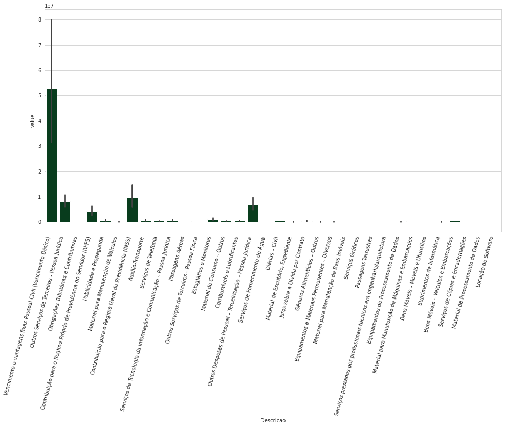

```python
plt.figure(figsize=(16,8))
plot = sns.barplot(
    data=despesas_com_classificacao,
    x='Descricao',
    y='value',
    estimator=sum,
    palette=sns.color_palette("BuGn_r", n_colors=len(despesas_com_classificacao) + 4)
)
plot.set_xticklabels(plot.get_xticklabels(), rotation=75, horizontalalignment='right')
plt.show()
```

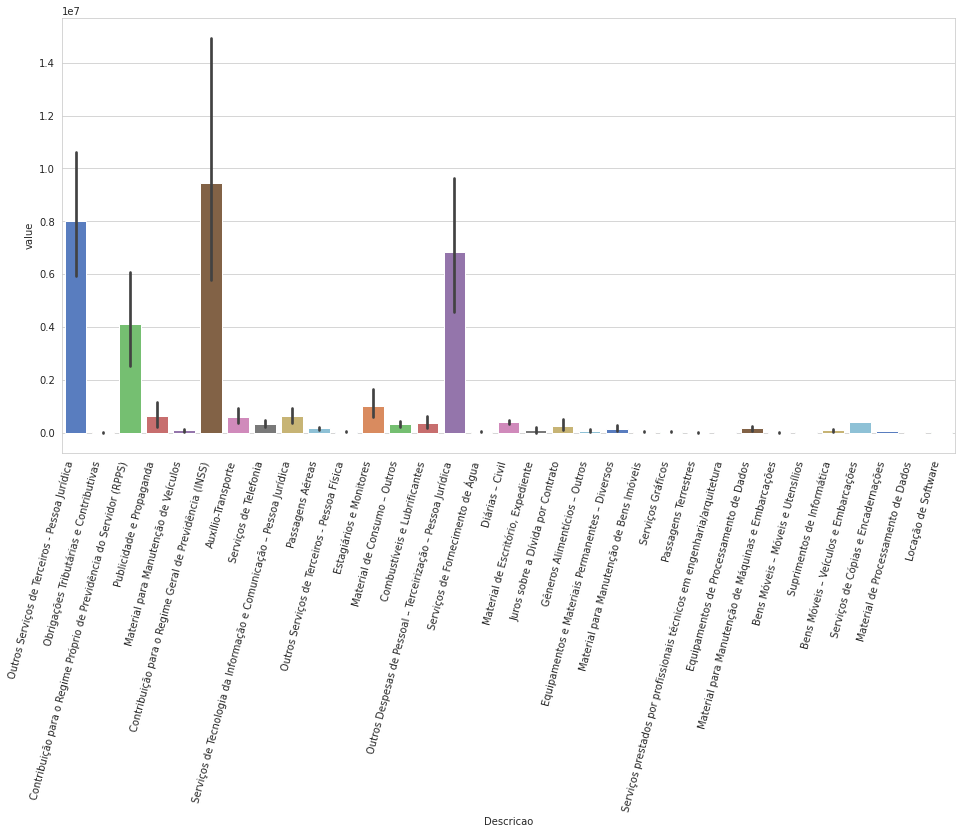

```python
vencimentos = ['Vencimentos e Vantagens Fixas - Pessoal Civil', 'Vencimento e vantagens fixas Pessoal Civil (Vencimento Básico)']
despesas_sem_vencimentos = despesas_com_classificacao[~despesas_com_classificacao['Descricao'].isin(vencimentos)]

plt.figure(figsize=(16,8))
plot = sns.barplot(
    data=despesas_sem_vencimentos,
    x='Descricao',
    y='value',
    estimator=sum,
    palette=sns.color_palette("muted", n_colors=len(despesas_sem_vencimentos) + 4)
)
plot.set_xticklabels(plot.get_xticklabels(), rotation=75, horizontalalignment='right')
plt.show()
```

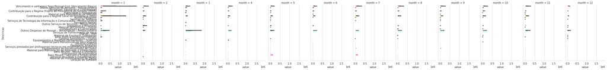

```python
sns.catplot(
    x="value",
    y="Descricao",
    col="month",
    data=despesas_com_classificacao, kind="bar",
    height=4, aspect=.7
)
```

```python
despesas_com_classificacao[['legal_status', 'subgroup', 'Descricao', 'summary', 'Codigo']].head(100)
```

|  | legal_status | subgroup | Descricao | summary | Codigo |
| --- | --- | --- | --- | --- | --- |
| 0 | 319011010000 - V.Vant.Fixas P.Civil(Ve.Base Fo... | V.Vant.Fixas P.Civil(Ve.Base Folha) | Vencimento e vantagens fixas Pessoal Civil (Ve... | REF. A VENCIMENTOS DOS SERVIDORES EFETIVOS, FO... | 31901101 |
| 1 | 319011010000 - V.Vant.Fixas P.Civil(Ve.Base Fo... | V.Vant.Fixas P.Civil(Ve.Base Folha) | Vencimento e vantagens fixas Pessoal Civil (Ve... | REF. A VENCIMENTOS DOS SERVIDORES CARGOS EM CO... | 31901101 |
| 2 | 339039999300000000 - Serviços Bancários ... | Serviços Bancários | Outros Serviços de Terceiros - Pessoa Jurídica | ANULACAO PARCIAL DO EMPENHO DE NUMERO 19000533 | 33903999 |
| 3 | NaN | NaN | NaN | PAGAMENTO EXTRA-ORCAMENTARIO NUMERO:000403 | NaN |
| 4 | NaN | NaN | NaN | PAGAMENTO EXTRA-ORCAMENTARIO NUMERO:000402 | NaN |
| ... | ... | ... | ... | ... | ... |
| 95 | 319113020000 - Cont.p/Reg.Proprio Prev.ser.RPP... | Cont.p/Reg.Proprio Prev.ser.RPPS | Contribuição para o Regime Próprio de Previdên... | REF. A OBRIGAÇÕES PATRONAIS SOBRE FOLHA DE PAG... | 31911302 |
| 96 | 339039999900 - Outros Serv.Terceiros - P. Juri... | Outros Serv.Terceiros - P. Juridica | Outros Serviços de Terceiros - Pessoa Jurídica | REF. A SERVIÇO DE EXECUÇÃO DO PLANEJAMENTO TÉC... | 33903999 |
| 97 | 339039010000000000 - Publicidades e Propaganda... | Publicidades e Propaganda | Publicidade e Propaganda | ANULACAO PARCIAL DO EMPENHO DE NUMERO 19000547 | 33903901 |
| 98 | 319113020000000000 - Cont.p/Reg.Proprio Prev.s... | Cont.p/Reg.Proprio Prev.ser.RPPS | Contribuição para o Regime Próprio de Previdên... | ANULACAO PARCIAL DO EMPENHO DE NUMERO 19000502 | 31911302 |
| 99 | 339039999900000000 - Outros Serv.Terceiros - P... | Outros Serv.Terceiros - P. Juridica - Demais s... | Outros Serviços de Terceiros - Pessoa Jurídica | ANULACAO PARCIAL DO EMPENHO DE NUMERO 19000018 | 33903999 |

100 rows × 5 columns

```python
# Auxílio-Alimentação
# Vale refeição/vale alimentação

# Encargos pela Honra de Avais, Garantias, Seguros e Similares
```

```python
# Locacao de Software / Locaçao de Software
# Materiais de Consumo - gás e outros / Materiais de Consumo - gás e outros materiais ...
```

```python
despesas = despesas[despesas['phase'] == 'pagamento']
despesas.describe()['value']
```

```
count               1,706.00
mean               16,744.04
std                65,200.25
min                -1,232.89
25%                   168.91
50%                   905.00
75%                 4,705.15
max               719,758.96
Name: value, dtype: float64
```

```python
pd.options.display.float_format = '{:20,.2f}'.format
despesas['value'].describe()
```

```
count               1,706.00
mean               16,744.04
std                65,200.25
min                -1,232.89
25%                   168.91
50%                   905.00
75%                 4,705.15
max               719,758.96
Name: value, dtype: float64
```

```python
despesas.nlargest(20, 'value')[['date', 'value', 'summary', 'subgroup', 'phase']]
```

|  | date | value | summary | subgroup | phase |
| --- | --- | --- | --- | --- | --- |
| 31693 | 2019-02-21 | 719,758.96 | REF. REMUNERAÇÃO DE FEVEREIRO 2019. | V.Vant.Fixas P.Civil(Ve.Base Folha) | pagamento |
| 32238 | 2019-04-17 | 694,826.01 | EF. A VENCIMENTOS DOS SERVIDORES CARGOS EM COM... | V.Vant.Fixas P.Civil(Ve.Base Folha) | pagamento |
| 31968 | 2019-03-21 | 691,621.10 | REF. A VENCIMENTOS DOS SERVIDORES CARGOS EM CO... | V.Vant.Fixas P.Civil(Ve.Base Folha) | pagamento |
| 32635 | 2019-05-20 | 684,911.34 | REF. REMUNERAÇÃO DE MAIO 2019. | V.Vant.Fixas P.Civil(Ve.Base Folha) | pagamento |
| 33792 | 2019-09-20 | 684,425.13 | REF. A VENCIMENTOS DOS SERVIDORES CARGOS EM CO... | V.Vant.Fixas P.Civil(Ve.Base Folha) | pagamento |
| 33421 | 2019-08-20 | 683,621.63 | REF. A VENCIMENTOS DOS SERVIDORES CARGOS EM CO... | V.Vant.Fixas P.Civil(Ve.Base Folha) | pagamento |
| 31665 | 2019-01-22 | 682,234.89 | REF. A VENCIMENTOS DOS SERVIDORES CARGOS EM CO... | V.Vant.Fixas P.Civil(Ve.Base Folha) | pagamento |
| 32980 | 2019-06-19 | 680,490.41 | REF. A VENCIMENTOS DOS SERVIDORES CARGOS EM CO... | V.Vant.Fixas P.Civil(Ve.Base Folha) | pagamento |
| 34395 | 2019-11-20 | 680,197.84 | REF. A VENCIMENTOS DOS SERVIDORES CARGOS EM CO... | V.Vant.Fixas P.Civil(Ve.Base Folha) | pagamento |
| 33173 | 2019-07-19 | 679,767.91 | REF. A VENCIMENTOS DOS SERVIDORES CARGOS EM CO... | V.Vant.Fixas P.Civil(Ve.Base Folha) | pagamento |
| 33974 | 2019-10-18 | 678,048.28 | REF. A VENCIMENTOS DOS SERVIDORES CARGOS EM CO... | V.Vant.Fixas P.Civil(Ve.Base Folha) | pagamento |
| 34761 | 2019-12-20 | 307,464.32 | REF. A VENCIMENTOS DOS SERVIDORES CARGOS EM CO... | V.Vant.Fixas P.Civil(Ve.Base Folha) | pagamento |
| 32843 | 2019-06-11 | 292,669.93 | REF A ADIANTAMENTO DO 13° SALÁRIO DOS SERVIDOR... | V.Vant.Fixas P.Civil(Ve.Base Folha) | pagamento |
| 34676 | 2019-12-12 | 283,967.22 | REF. A 2ª PARCELA DO 13º SALÁRIO DOS SERVIDORE... | V.Vant.Fixas P.Civil(Ve.Base Folha) | pagamento |
| 33966 | 2019-10-18 | 210,484.68 | REF. A VENCIMENTOS DOS SERVIDORES EFETIVOS, MÊ... | V.Vant.Fixas P.Civil(Ve.Base Folha) | pagamento |
| 32968 | 2019-06-19 | 207,105.85 | REF. A VENCIMENTOS DOS SERVIDORES EFETIVOS, MÊ... | V.Vant.Fixas P.Civil(Ve.Base Folha) | pagamento |
| 34318 | 2019-11-20 | 200,554.12 | REF. A VENCIMENTOS DOS SERVIDORES EFETIVOS, MÊ... | V.Vant.Fixas P.Civil(Ve.Base Folha) | pagamento |
| 32237 | 2019-04-17 | 200,368.32 | REF. A VENCIMENTOS DOS SERVIDORES EFETIVOS, MÊ... | V.Vant.Fixas P.Civil(Ve.Base Folha) | pagamento |
| 34775 | 2019-12-20 | 199,000.00 | REF. A VENCIMENTOS DOS SERVIDORES CARGOS EM CO... | V.Vant.Fixas P.Civil(Ve.Base Folha) | pagamento |
| 32335 | 2019-04-22 | 192,309.26 | REF. A OBRIGAÇÕES PATRONAIS SOBRE FOLHA DE PAG... | Cont.p/Reg.Geral Prev.INSS | pagamento |

```python
despesas.nsmallest(20, 'value')[['date', 'value', 'summary', 'subgroup', 'phase']]
```

|  | date | value | summary | subgroup | phase |
| --- | --- | --- | --- | --- | --- |
| 33884 | 2019-10-04 | -1,232.89 | NaN | V.Vant.Fixas P.Civil(Ve.Base Folha) | pagamento |
| 31571 | 2019-01-23 | 0.50 | PAGAMENTO EXTRA-ORCAMENTARIO NUMERO:000022 | NaN | pagamento |
| 33941 | 2019-10-09 | 1.38 | REF. A TARIFA BANCÁRIA SOBRE CONTA DESTA CASA. | Serviços Bancários | pagamento |
| 32414 | 2019-05-06 | 1.38 | REF. A TARIFA BANCÁRIA SOBRE CONTA DESTA CASA. | Serviços Bancários | pagamento |
| 33613 | 2019-09-11 | 1.62 | REF. A TARIFA BANCÁRIA SOBRE CONTA DESTA CASA. | Serviços Bancários | pagamento |
| 33503 | 2019-09-02 | 1.62 | REF. A TARIFA BANCÁRIA SOBRE CONTA DESTA CASA. | Serviços Bancários | pagamento |
| 33412 | 2019-08-07 | 1.62 | REF. A TARIFA BANCÁRIA SOBRE CONTA DESTA CASA. | Serviços Bancários | pagamento |
| 33078 | 2019-07-05 | 1.62 | REF. A TARIFA BANCÁRIA SOBRE CONTA DESTA CASA. | Serviços Bancários | pagamento |
| 31619 | 2019-02-18 | 1.62 | REF. TARIFA BANCARIA NESTA DATA. | Serviços Bancários | pagamento |
| 31392 | 2019-01-16 | 1.62 | REF. A TARIFA BANCÁRIA SOBRE CONTA DESTA CASA. | Serviços Bancários | pagamento |
| 32961 | 2019-06-18 | 2.76 | REF. A TARIFA BANCÁRIA SOBRE CONTA DESTA CASA. | Serviços Bancários | pagamento |
| 31725 | 2019-03-07 | 2.76 | REF. TARIFA BANCARIA NESTA DATA. | Serviços Bancários | pagamento |
| 34148 | 2019-11-08 | 3.24 | REF. A TARIFA BANCÁRIA SOBRE CONTA DESTA CASA. | Serviços Bancários | pagamento |
| 34438 | 2019-11-06 | 3.24 | REF. A TARIFA BANCÁRIA SOBRE CONTA DESTA CASA. | Serviços Bancários | pagamento |
| 33553 | 2019-08-20 | 3.24 | REF. A TARIFA BANCÁRIA SOBRE CONTA DESTA CASA. | Serviços Bancários | pagamento |
| 32925 | 2019-06-17 | 3.24 | REF. A TARIFA BANCÁRIA SOBRE CONTA DESTA CASA. | Serviços Bancários | pagamento |
| 31387 | 2019-01-11 | 3.24 | REF. A TARIFA BANCÁRIA SOBRE CONTA DESTA CASA. | Serviços Bancários | pagamento |
| 34933 | 2019-12-26 | 3.99 | PAGAMENTO EXTRA-ORCAMENTARIO NUMERO:000400 | NaN | pagamento |
| 32791 | 2019-06-05 | 4.38 | REF. A TARIFA BANCÁRIA SOBRE CONTA DESTA CASA. | Serviços Bancários | pagamento |
| 34232 | 2019-11-26 | 4.65 | REF. A TARIFA BANCÁRIA SOBRE CONTA DESTA CASA. | Serviços Bancários | pagamento |

## Quem foram os fornecedores?

```python
pd.pivot_table(
    despesas,
    values='value',
    index=['company_or_person'],
    columns='month',
    aggfunc=np.sum
).sort_values(by='company_or_person', ascending=False)
```

| month company_or_person | 1 | 2 | 3 | 4 | 5 | 6 | 7 | 8 | 9 | 10 | 11 | 12 |
| --- | --- | --- | --- | --- | --- | --- | --- | --- | --- | --- | --- | --- |
| WELLIGTON ANDRADE DE JESUS | nan | nan | nan | 1,320.00 | nan | nan | nan | nan | nan | nan | nan | nan |
| W. AGUIAR CABRAL DOS SANTOS SONORIZAÇÃO - ME | nan | 1,249.16 | 1,258.06 | nan | 2,516.60 | 1,259.12 | 1,259.66 | 1,260.31 | 1,260.31 | 1,260.63 | 1,261.67 | 2,525.50 |
| VIPSEL SEGURANÇA MONITORADA EIRELI ME | nan | nan | nan | nan | 690.46 | 690.46 | 690.46 | 689.38 | 689.38 | nan | 689.31 | nan |
| VIP'SEL SEGURANÇA MONITORADA EIRELI ME | nan | 691.53 | 690.96 | 690.53 | nan | nan | nan | nan | nan | nan | nan | nan |
| VIDROCA COML. DE VIDROS E CALH | nan | nan | nan | nan | nan | nan | nan | nan | nan | nan | 92.15 | nan |
| ... | ... | ... | ... | ... | ... | ... | ... | ... | ... | ... | ... | ... |
| ALLIANZ SEGUROS S/A | nan | nan | nan | nan | nan | 1,936.91 | nan | nan | nan | nan | nan | nan |
| ALDNEY BASTOS MARQUES | nan | nan | nan | nan | 3,600.00 | nan | nan | nan | nan | nan | nan | nan |
| ALBERTO MATOS NERY | nan | nan | nan | nan | nan | 3,600.00 | nan | nan | 1,350.00 | nan | 400.00 | nan |
| AILTON OLIVEIRA BRITO JUNIOR | nan | nan | nan | nan | nan | nan | nan | nan | nan | nan | nan | 125.00 |
| 305 COMERCIO DE UTILIDADES DO | nan | nan | nan | nan | 1,290.70 | nan | nan | nan | nan | nan | nan | nan |

177 rows × 12 columns

```python
def to_csv(despesas, arquivo='todas-as-despesas-desde-2016.csv'):
    despesas.to_csv(
        arquivo,
        index=False,
        columns=["published_at", "phase", "company_or_person", "value", "number", "document", "date", "process_number", "summary", "group", "function", "subfunction", "type_of_process", "resource"],
        header=["publicado_em", "fase", "empresa_ou_pessoa", "valor", "numero", "documento", "data", "numero_do_processo", "sumario", "grupo", "funcao", "subfuncao", "type_of_process", "fonte"]
    )
```

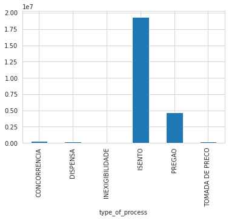

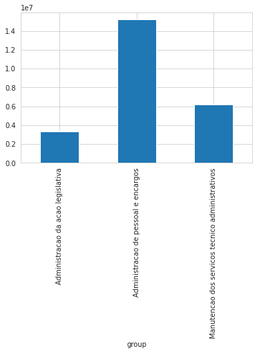

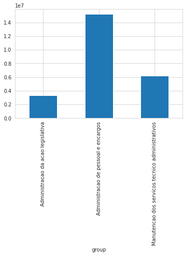

```python
despesas.groupby('type_of_process')['value'].sum().plot(kind='bar')
plt.show()

despesas.groupby('group')['value'].sum().plot(kind='bar')
plt.show()

despesas.groupby('group')['value'].sum().plot(kind='bar')
plt.show()
```

```python
despesas.group.value_counts()
```

```
Manutencao dos servicos tecnico administrativos    875
Administracao de pessoal e encargos                434
Administracao da acao legislativa                   83
Name: group, dtype: int64
```

```python
despesas.company_or_person.value_counts()
```

```
CAIXA ECONOMICA FEDERAL                                  172
IPFS - INST. DE PREV. DOS SERV                           101
REDE GERAL SERVIÇOS LTDA ME                               65
FUNCIONARIOS CARGOS EM COMISSA                            55
INSS - INST. NAC. DE SEG. SOCI                            51
                                                        ...
JAI TRANSPORTE E COMÉRCIO DE GÁS LTDA                      1
DNIT-DEPARTAMENTO NACIONAL DE INFRAEST DE TRANSPORTES      1
JOÃO DOS SANTOS                                            1
RODRIGUES E FARIAS LTDA.                                   1
ROBECI SILVA LIMA                                          1
Name: company_or_person, Length: 177, dtype: int64
```

```python
despesas.groupby(['company_or_person']).sum().groupby(level=[0])['value'].cumsum().sort_values(ascending=False)
```

```
company_or_person
FUNCIONARIOS CARGOS EM COMISSA                                 8,934,114.84
INSS - INST. NAC. DE SEG. SOCI                                 3,100,402.72
FUNCIONARIOS EFETIVOS                                          2,520,349.98
VEREADORES                                                     2,452,739.15
ESFERA PRODUÇÃO E EVENTOS EIRELI-ME                            1,616,129.37
                                                               ...
MARIA CLARA PIRES DA PURIFICAÇÃO                                     125.00
VIDROCA COML. DE VIDROS E CALH                                        92.15
PROTONLUZ COMERCIO DE MATERIAIS ELEÉTRICOS LTDA - ME                  66.80
RETENCOES DIVERSAS                                                    40.19
DESCONTO AUTORIZADO                                                    0.50
Name: value, Length: 177, dtype: float64
```

## O que a Câmara consome mais em cada categoria?

```python
despesas_com_classificacao['summary'].describe()
```

```
count                                               3696
unique                                              1876
top       REF. A TARIFA BANCÁRIA SOBRE CONTA DESTA CASA.
freq                                                 276
Name: summary, dtype: object
```

```python
despesas_com_classificacao[['Descricao', 'Codigo', 'summary', 'value']].tail(20)
```

|  | Descricao | Codigo | summary | value |
| --- | --- | --- | --- | --- |
| 3689 | Outros Serviços de Terceiros - Pessoa Jurídica | 33903999 | IMPORTE DESTINADO A PAGAMENTO DE DESPESAS COM ... | 120,000.00 |
| 3690 | Gêneros Alimentícios – Outros | 33903012 | IMPORTE DESTINADO A GENEROS ALIMENTICIOS | 10,000.00 |
| 3691 | Outros Serviços de Terceiros - Pessoa Jurídica | 33903999 | IMPOSTE DESTINADO A PAGAMENTO DE DESPESA COM T... | 104,800.00 |
| 3692 | Passagens Aéreas | 33903301 | IMPORTE DESTINADO A PAGAMENTO DE PASSAGENS AEREAS | 10,000.00 |
| 3693 | Outros Serviços de Terceiros - Pessoa Jurídica | 33903999 | IMPOSTE DESTINADO A PAGAMENTO DE DESPESA COM S... | 10,800.00 |
| 3694 | Serviços de Telefonia | 33903909 | IMPORTE DESTINADO A PAGAMENTO DE DESPESAS COM ... | 26,608.00 |
| 3695 | Locação de Software | 44903915 | IMPOSTE DESTINADO A PAGAMENTO DE DESPESAS COM ... | 1,260.00 |
| 3696 | Serviços de Telefonia | 33903909 | IMPORTE DESTINADO A DESPESA DE PAGAMENTO COM T... | 5,400.00 |
| 3697 | NaN | NaN | IMPORTE DESTINADO A PAGAMENTO DE DIVIDA PREVID... | 44,875.08 |
| 3698 | Serviços de Telefonia | 33903909 | IMPOSTE DESTINADO A PAGAMENTO DE DESPESAS COM ... | 26,608.00 |
| 3699 | Obrigações Tributárias e Contributivas | 33904700 | IMPORTE DESTINADO A PAGAMENTO DE INSS(SERVIÇO) | 10,000.00 |
| 3700 | NaN | NaN | SERVIÇO DE REMANUFATURA DE CARTUCHOS HP PARA A... | 3,000.00 |
| 3701 | Auxílio-Transporte | 33904900 | IMPORTE DESTINADO A PAGAMENTO DE AUX TRANSPORT... | 140,000.00 |
| 3702 | Outros Serviços de Terceiros - Pessoa Jurídica | 33903999 | IMPORTE DESTINADO A PAGAMENTO DE DESPESAS COM ... | 6,675.00 |
| 3703 | Outros Serviços de Terceiros - Pessoa Jurídica | 33903999 | IMPORTE DESTINADO A PAGAMENTO DE DESPESAS COM ... | 1,300.00 |
| 3704 | Outros Serviços de Terceiros - Pessoa Jurídica | 33903999 | IMPORTE DESTINADO A PAGAMENTO DE DESPESAS COM ... | 10,000.00 |
| 3705 | Outros Serviços de Terceiros - Pessoa Jurídica | 33903999 | IMPORTE DESTINADO A PAGAMENTO DE DESPESAS COM ... | 10,000.00 |
| 3706 | Outros Serviços de Terceiros - Pessoa Jurídica | 33903999 | IMPOSTE DESTINADO A PAGAMENTO DE DESPESAS COM ... | 2,340.00 |
| 3707 | Outros Serviços de Terceiros - Pessoa Jurídica | 33903999 | IMPORTE DESTINADO A PAGAMENTO DE DESPESA COM T... | 104,800.00 |
| 3708 | Outros Serviços de Terceiros - Pessoa Jurídica | 33903999 | IMPORTE DESTINADO A PAGAMENTO DE DESPESAS COM ... | 1,120.00 |

```python
despesas.groupby(
    ['company_or_person', 'document']
).size().reset_index().rename(columns={0: 'count'}).sort_values('count', ascending=False)
```

|  | company_or_person | document | count |
| --- | --- | --- | --- |
| 17 | CAIXA ECONOMICA FEDERAL | 00.360.305/1611-16 | 172 |
| 84 | IPFS - INST. DE PREV. DOS SERV | 42.743.658/0001-33 | 101 |
| 139 | REDE GERAL SERVIÇOS LTDA ME | 08.241.186/0001-82 | 65 |
| 66 | FUNCIONARIOS CARGOS EM COMISSA | 14.488.415/0001-60 | 55 |
| 83 | INSS - INST. NAC. DE SEG. SOCI | 29.979.036/0001-40 | 51 |
| ... | ... | ... | ... |
| 73 | HARLEN DA SILVA ALMEIDA | 09.442.874/0001-73 | 1 |
| 71 | GILMAR AMORIM DE OLIVEIRA | 733.533.025-49 | 1 |
| 70 | GERUSA MARIA BASTOS S. SAMPAIO | 272.179.495-72 | 1 |
| 62 | FAGUNDES E BITENCOURT DESPACHANTES LTDA | 29.780.653/0001-12 | 1 |
| 176 | WELLIGTON ANDRADE DE JESUS | 248.035.295-15 | 1 |

177 rows × 3 columns

```
tipo_de_pessoa
física       304
jurídica    1402
dtype: int64
```

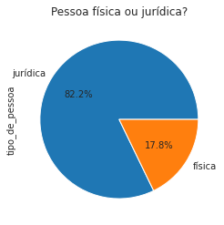

```python
import re


padrao = {
    re.compile('\d{2}.?\d{3}.?\d{3}/?\d{4}-?\d{2}'): "jurídica",
    re.compile('\d{3}\.\d{3}\.\d{3}\-\d{2}'): "física"
}


despesas['tipo_de_pessoa'] = despesas['document'].replace(padrao, regex=True)
print(despesas.groupby(['tipo_de_pessoa']).size())

despesas['tipo_de_pessoa'].value_counts().plot.pie(
    y='tipo_de_pessoa', title="Pessoa física ou jurídica?", autopct='%1.1f%%', startangle=0
)
```